# Lab 13

January 23rd 2018

## Bayesian Analysis of Factorial Desings

## Why factorial designs?

- Say we are interested in how some miracle diet affects weight loss.
- We are conducting a simple study and compare no diet to miracle diet.

## Why factorial designs?

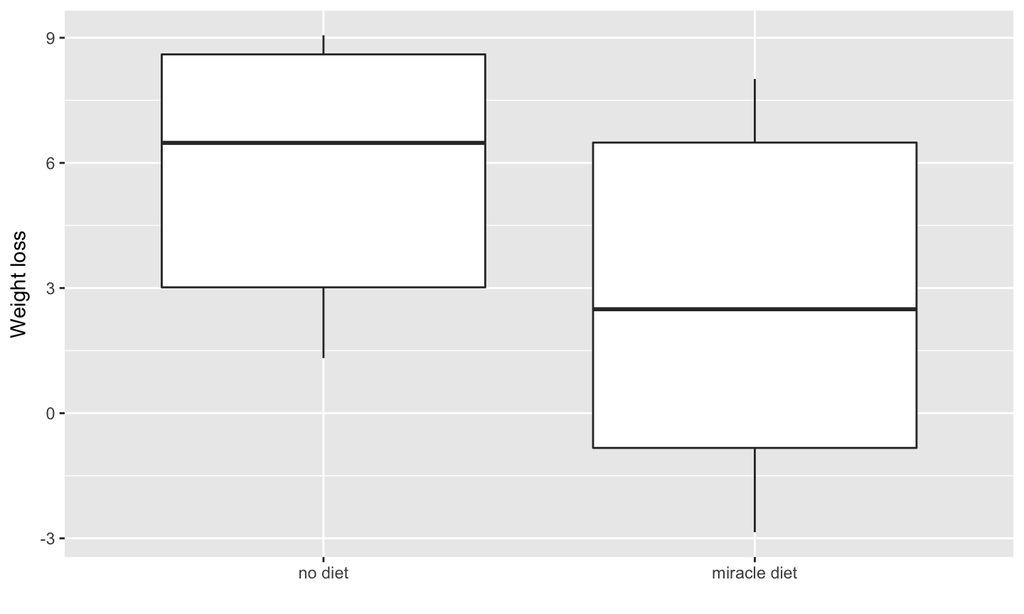

## Why factorial designs?

- Ahh, the miracle diet…What is really important is a proper workout.
- We should conduct another experiment, should we?

## Why factorial designs?

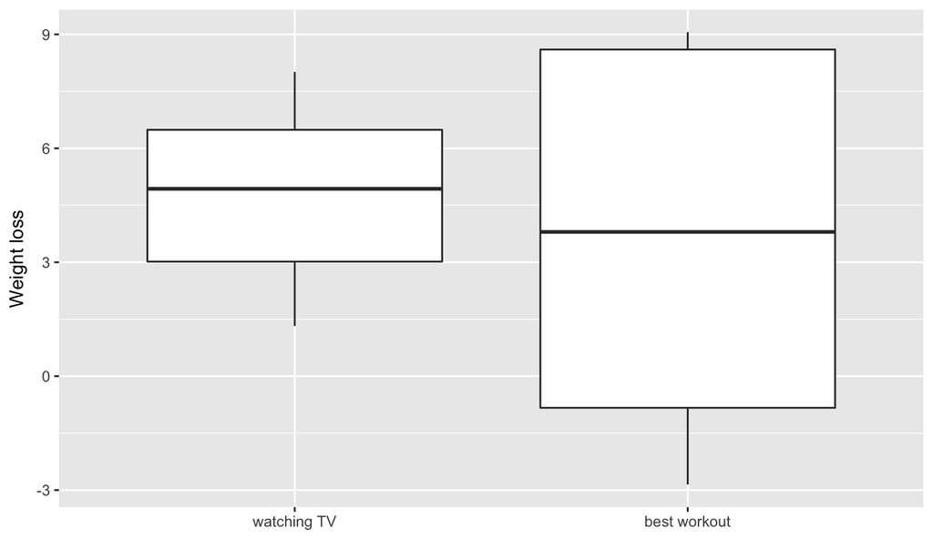

## Why factorial designs?

- If we know in advance important *n* factors responsible for changes in DV, we should rather conduct *n* factorial experiment.
- E.g. with diet and workout.

## Why factorial designs?

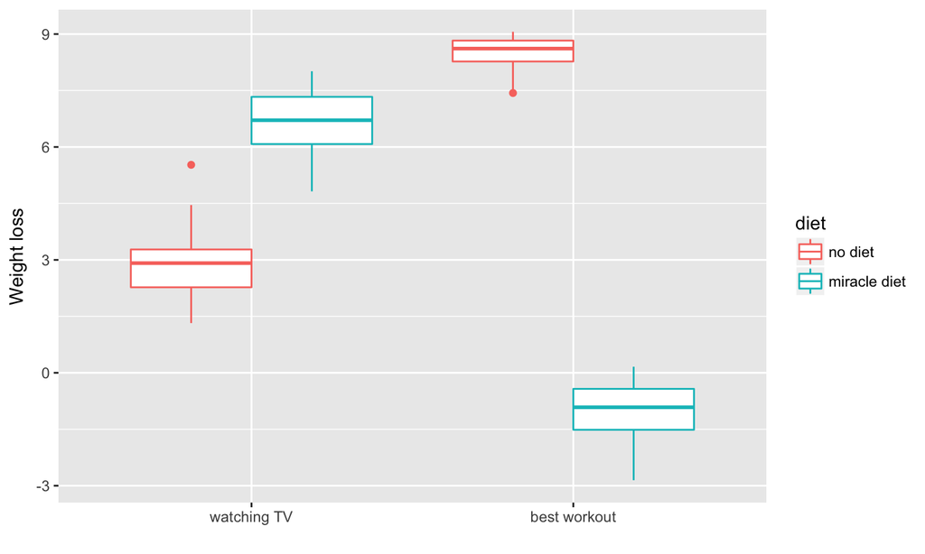

## Model for factorial designs

\(y_{ijk} = \alpha + \beta_{1j} + \beta_{2k} + \beta_{1\times2jk} + \epsilon_{ijk}\)

- \(\alpha\) - grand mean
- \(\beta_{1j}\) - effect of factor 1 for level indicated by subscript \(j\)
- \(\beta_{2k}\) - effect of factor 2 for level indicated by subscript \(k\)
- \(\beta_{1\times2jk}\) - interactive effect of factors 1 and 2 for their levels indicated by subscripts \(j\) and \(k\)
- \(\epsilon_{ijk}\) - individual level variation for a subject \(i\) in groups \(j\) of factor 1 and \(k\) of factor 2
- we assume that \(E(\epsilon_{ijk})\) and \(Var(\epsilon_{ijk}) = \sigma^2\), ie. variance does not depend on group membership

## Understanding the model

- Say \(\alpha = 4.5\)

|  | no diet | diet |
| --- | --- | --- |
| watching TV | 4.5 | 4.5 |
| workout | 4.5 | 4.5 |

## Understanding the model

- Say \(\beta_{1j}\) refers to diet, and is equal to a vector of length equal to the number of levels of diet: (-2, 2)

|  | no diet | diet |
| --- | --- | --- |
| watching TV | 2.5 | 6.5 |
| workout | 2.5 | 6.5 |

## Understanding the model

- Say \(\beta_{2j}\) refers to workout, and is equal to a vector of length equal to the number of levels of workout: (-3, 3)

|  | no diet | diet |
| --- | --- | --- |
| watching TV | 1.5 | 1.5 |
| workout | 7.5 | 7.5 |

## Understanding the model

- The additive effect of \(\beta_{1j}\) and \(\beta_{2j}\) is just a combination of previous operations

|  | no diet | diet |
| --- | --- | --- |
| watching TV | -0.5 | 3.5 |
| workout | 5.5 | 9.5 |

## Understanding the model

- What's left are interaction terms, which are specific to each cell (ie. each combination of factors)
- Say we have this interaction effects:

|  | no diet | diet |
| --- | --- | --- |
| watching TV | -1 | 1 |
| workout | 1 | -1 |

## Understanding the model

- When we add respective cells we will obtain estimated means

|  | no diet | diet |
| --- | --- | --- |
| watching TV | -1.5 | 4.5 |
| workout | 6.5 | 8.5 |

## Bayesian factorial model

- The implementation follows the guidelines of Kruschke
- We assume \(y_{ijk} \sim \mathcal{N}(\mu_{jk}, \sigma^2_y)\)
- \(\sigma^2_y \sim \mathcal{U(low,high)}\) where low and high indicate values respective to the scale of the DV
- \(\mu_{jk} = \alpha + \beta_{1j} + \beta_{2k} + \beta_{1\times2jk}\)
- \(\alpha \sim \mathcal{N}(M, S^2)\) where M and S are mean and multiple of observed DV variance
- \(\beta_{xj} \sim \mathcal{N}( 0.0, \sigma^2_x )\), are deflections related to \(x\) (where \(x\) is factor 1, 2, or interaction)
- \(\sigma^2_x \sim \mathcal{G}(Shape,Rate)\), are variances/standard deviations of deflections related to \(x\) (where \(x\) is factor 1, 2, or interaction), and shape and rate are calculated w.r.t distribution of DV